# Sprawozdanie 2

Eksploracja danych

Kacper Szmigielski, 282255 i Mateusz Wizner, 277508

2025-04-30

# ZADANIE 1 (Dyskretyzacja(przedziałowanie) cech ciągłych)

## a) Dane: iris (R-pakiet datasets).

Zbiór danych zawiera wyniki pomiarów uzyskanych dla **trzech gatunków irysów** (tj. setosa, versicolor i virginica) i został **udostępniony przez Ronalda Fishera w roku 1936.**

– **Pomiary** dotyczą **długości oraz szerokości** dwóch różnych części kwiatu– działki **kielicha (ang. sepal) oraz płatka (ang. petal).**

## b) Wybór cech

**Szukamy cech, których róznice są najbardziej spójne z różnicami pomiędzy gatunkami.**

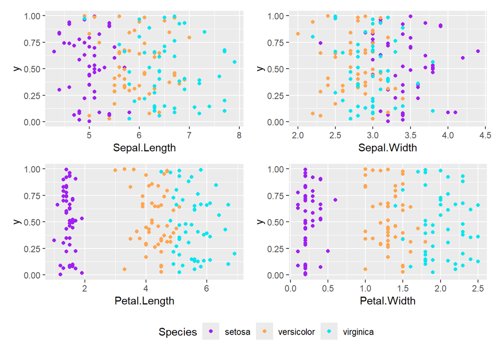

Po przeanalizowaniu scatter-plotów, widać ,że podczas szukania cechy o najlepszej zdolności dyskretyzacyjnej warto zwrócić uwagę na **Petal.Length i Petal.Width**, natomiast jeżeli poszukujemy kolumny o najgorszej zdolności dyskretyzacyjnej to wybór rozsztrzygamy spośród **Sepal.Length i Sepal.Width**

Musimy jednak wybrać **wartości najlepsze i najgorsze** do dysktetyzacji, aby to zrobić przeanalizujemy **box-ploty**.

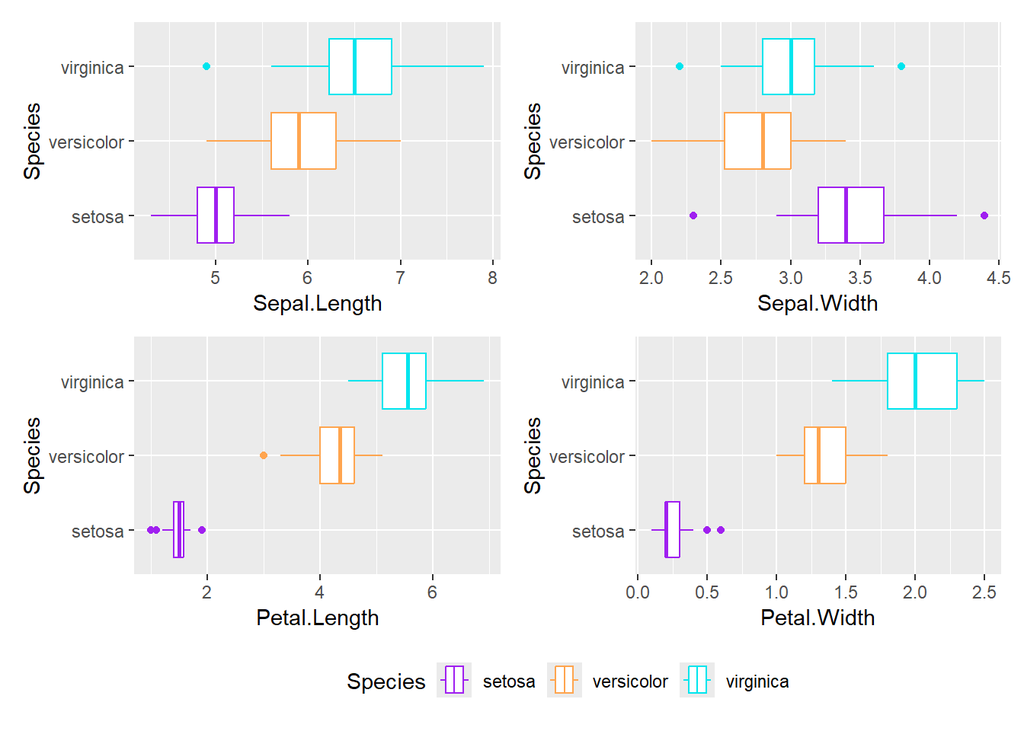

## c) Porównanie nienadzorowanych metod dyskretyzacji

### Metoda : Równe częstości(Frequency)

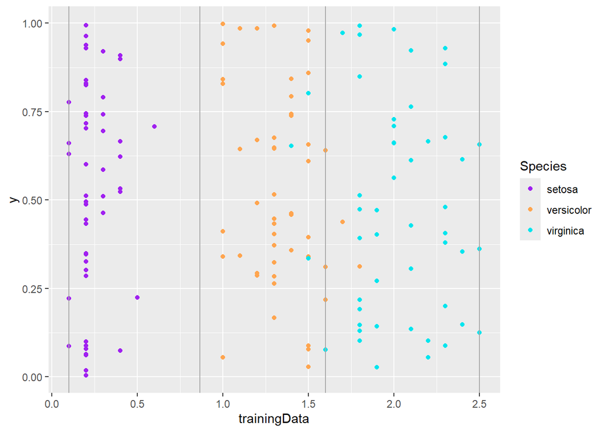

Widać, że linie uzyskane za pomocną **Frequency** dość dobrze rozdzielają nasze dane .

Jeżeli chcemy dokładniej przeanalizować zależność podziału od gatunków, narysujemy specjalne bar-ploty

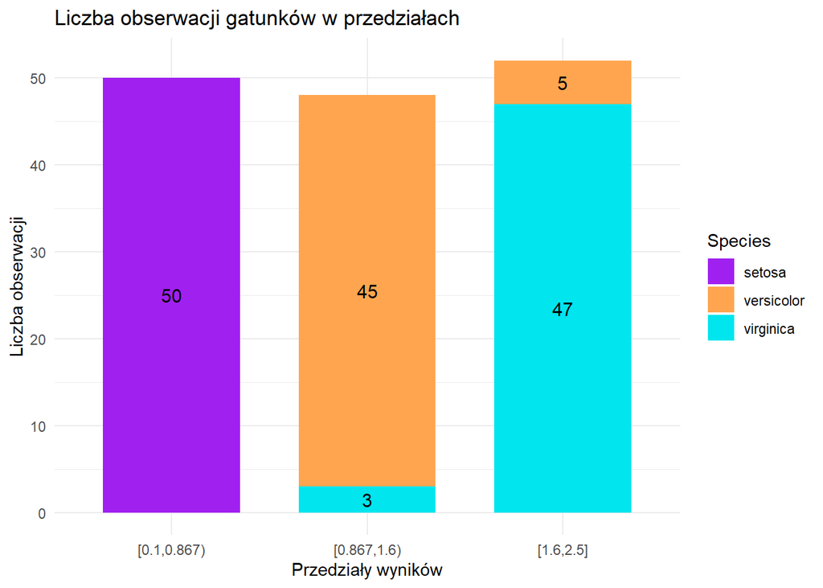

Świadczą one o tym, że metoda Frequency dla zmiennej **Petal.Width** bezproblemowo oddziela gatunek setosa, lecz wśród pozostałych występuje zjawisko mieszania się (3 virginica przyporządkowano do versicolor, a 5 versicolor do virginica)

W przypadku tej metody **zgodność** uzyskanego grupowania z realnymi wartościami **wynosi** :

```
## [1] 0.9466667
```

#### Dla najgorszej cechy : Sepal.Length (Frequency)

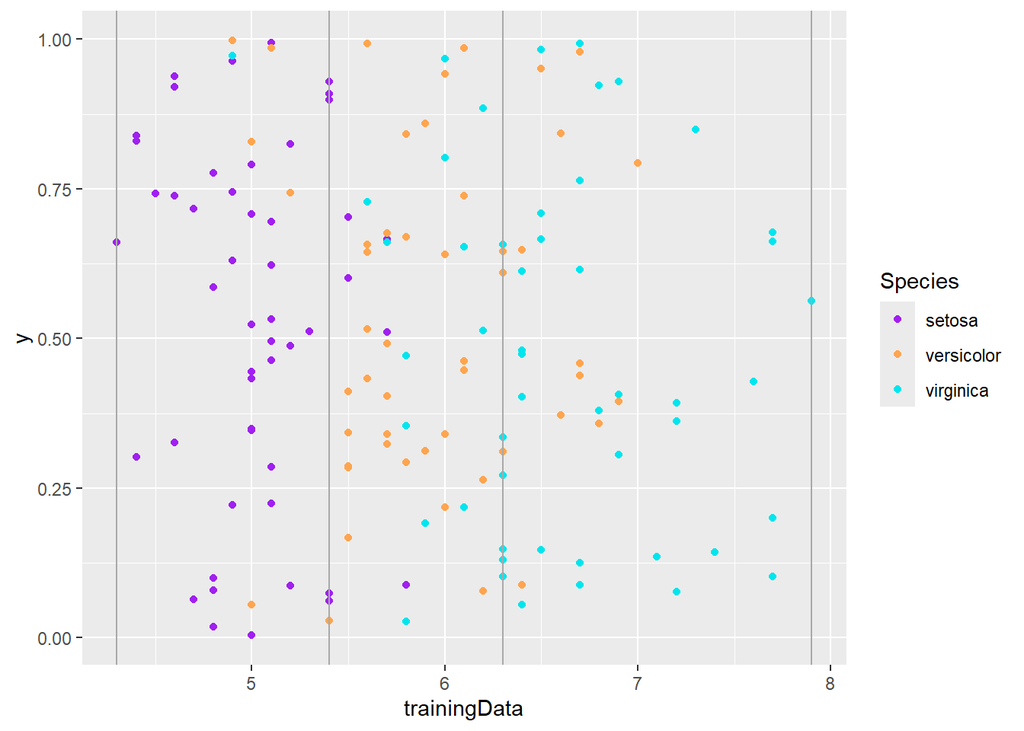

Scatter-plot wskazuje, że dla Sepal.Length grupowanie może być dość problematyczne, widać, że obserwacje są dość wymieszane, i trudno będzie w prosty sposób oddzielić je tak, aby gatunki były prawidłowo rozłożożone, te sam problem pojawia się w pozostałych metodach grupowań, dlatego scatter-plot Sepal.Length analizujemy tylko tutaj.

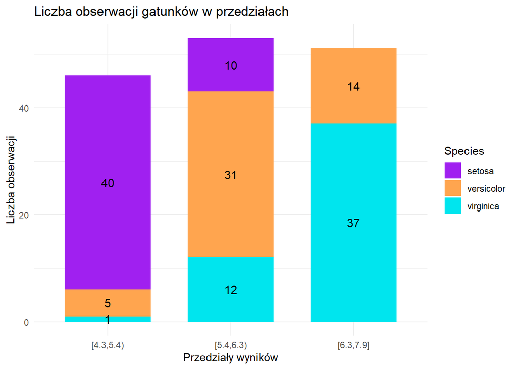

Na tabeli przyporządkowań widać, problemy metody Frequency, przy grupowaniu dla zmiennej Sepal.Length, gatunki są dość mocno przemieszane, brakuje jednolitego podziału.

```
## [1] 0.72
```

Zgodność dla nagjroszej cechy wynosi jedynie ok **72%**, co mówi o znacznym spadku wiarygodności (**o ok 23 %**) w porównaniu do Petal.Width

### Metoda : Równe szerokości (Interval)

#### Dla najlepszej cechy : Petal.Width (Interval)

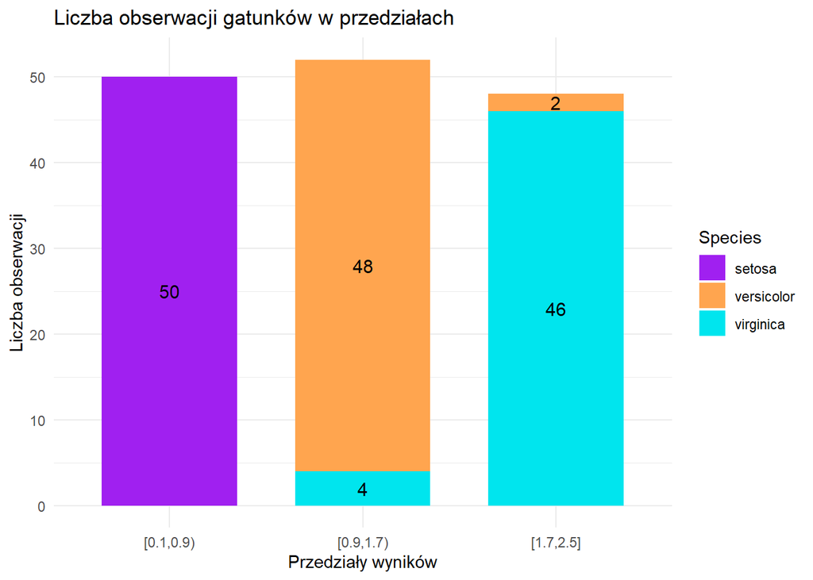

Po tabeli przyporządkowań widać, że mamy trochę lepsze odróżnienienie versicolor od virginica

Dla tej metody również mamy **zgodność na poziomie** :

```
## [1] 0.96
```

Widać lekki wzrost zgodności w porównaniu do poprzedniej metody (**o ok 1%**)

#### Dla najgorszej cechy ; Sepal.Length (Interval)

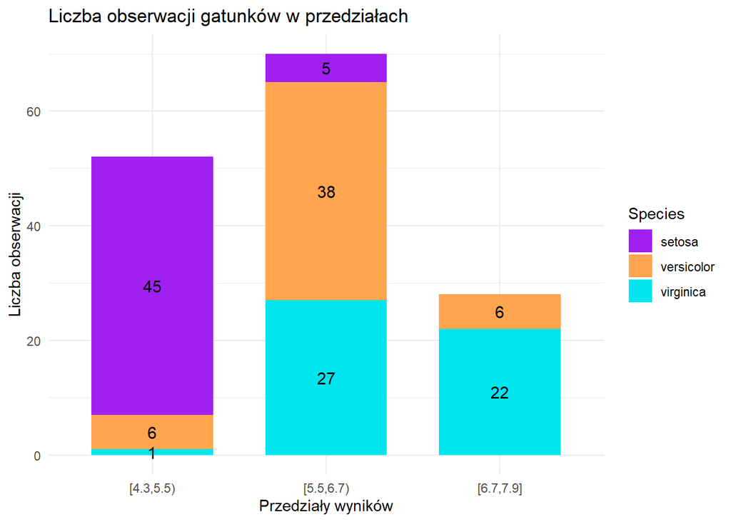

Dla tabeli zgodności widać, że metoda w zły sposób rozdziela przypadki. Bardzo duża ich ilość znajduje się w środkowym przedziale, więc nie jest to dobry podział gatunkowy

Metoda ta, dla najgorszej cechy dyskretyzuje ze zgodnością :

[output not shown]

### Metoda : k najbliższych sąsiadów (K-means)

#### Dla najlepszej cechy : Petal.Width (K-means)

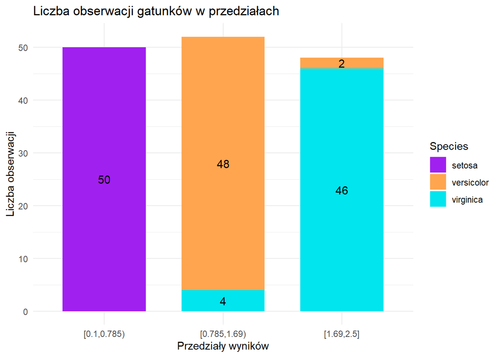

Analogiczny podział jak w poprzedniej metodzie

Zgodność na poziomie :

[output not shown]

#### Dla najgorszej cechy : Sepal.Length (K-means)

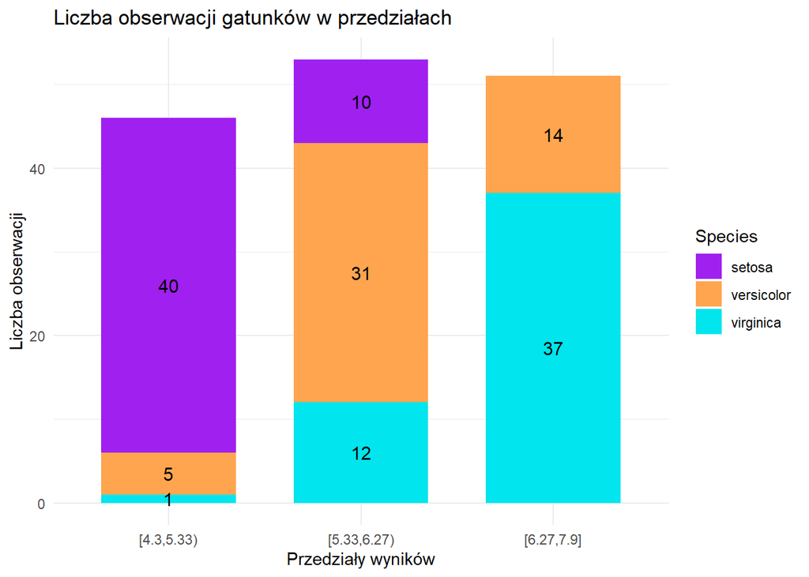

Bardziej równomierne rozłożenie niż w metodzie poprzedniej, lecz nie jest wciąż dobre pod względem gatunkowym.

Dla najgorszej cechy mamy zgodność :

```
## [1] 0.72
```

### Dyskretyzacja z przedziałami zadanymi przez urzytkownika (fixed)

#### Dla najlepszej cechy : Petal.Width (fixed)

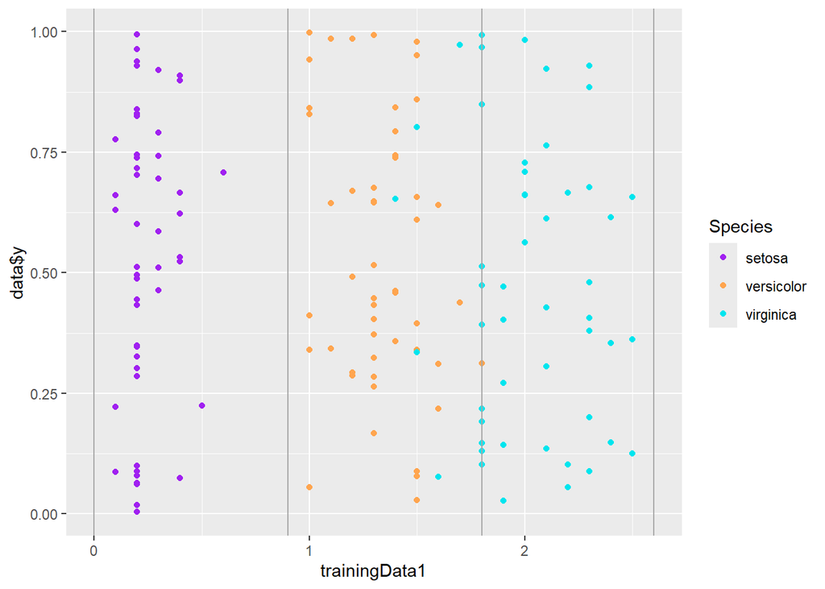

Na wykresie mamy zaznaczone też końce przedziałów, co jest potrzebne podczas wizualizacji przedziałów zadanych przez użytkownika.

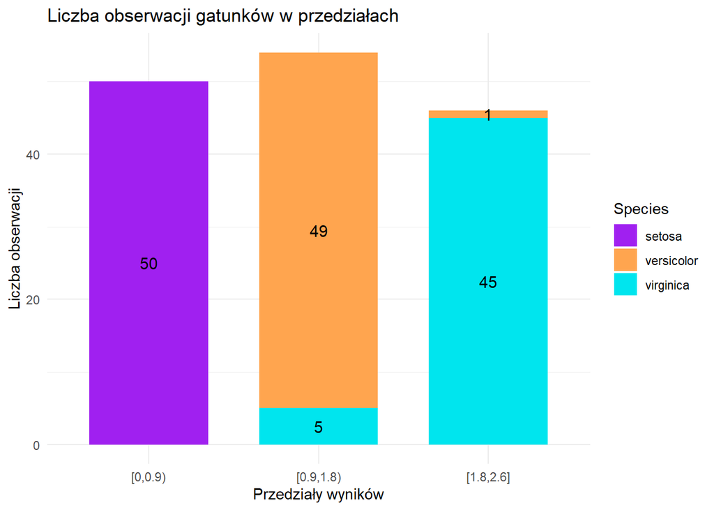

Mamy najmniejsze rozmieszanie virignica i versicolor. Tylko 1 versicolor została źle przyporządkowana w porównaniu do aż 5 virginic.

Zgodność na poziome poprzednich dwóch metod, wynosi :

```
## [1] 0.96
```

#### Dla najgorszej cechy : Sepal.Length (fixed)

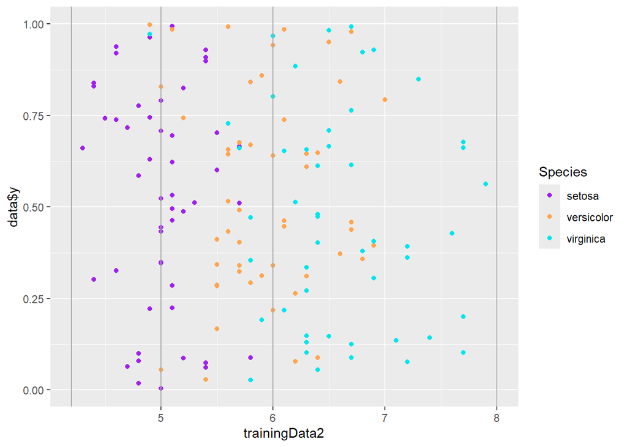

[figure not shown]

Równomierny rozkład między pierwszymi dwoma przedziałami ale dalej nierozróżnialne na postawie tej metody, więc nie powinniśmy używać jej do dyskretyzacji.

Dla cechy o najgorszej zdolności dyskretyzacynej:

```
## [1] 0.72
```

## Wnioski :

**Porównamy teraz** zgodności procentowe **wyników**, dla **poszczególnych algorytmów**

[output not shown]

# ZADANIE 2 (Analizaskładowych głównych (Principal Component Analysis (PCA)))

## a) Przygotowanie danych

Podstawowe informacje nt. danych `uaScoresDataFrame`

| rows | 266 |
| --- | --- |
| columns | 21 |
| discrete_columns | 3 |
| continuous_columns | 18 |
| all_missing_columns | 0 |
| total_missing_values | 0 |
| complete_rows | 266 |
| total_observations | 5586 |
| memory_usage | 73496 |

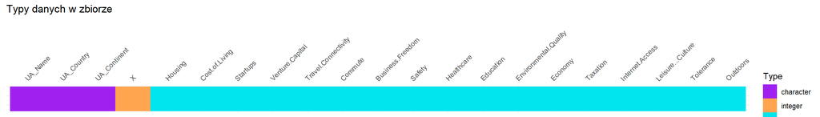

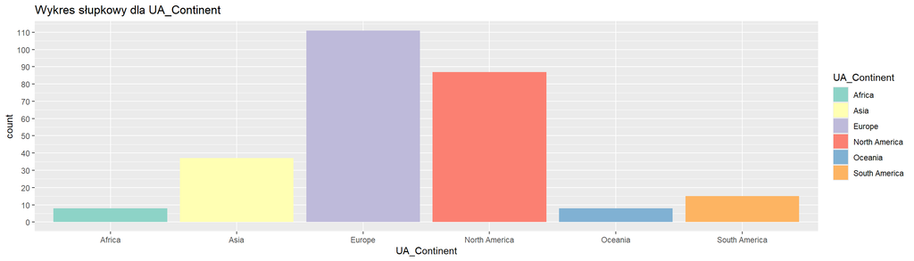

kolo

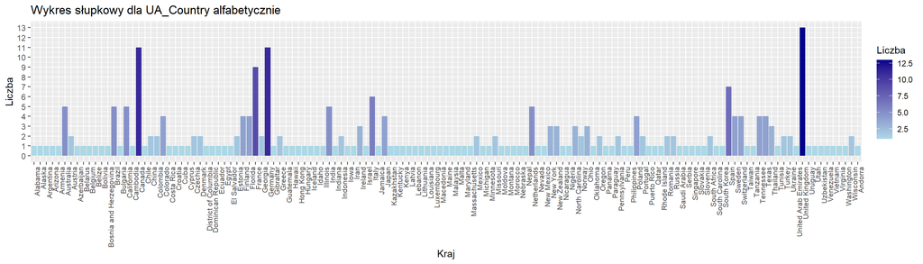

kolo

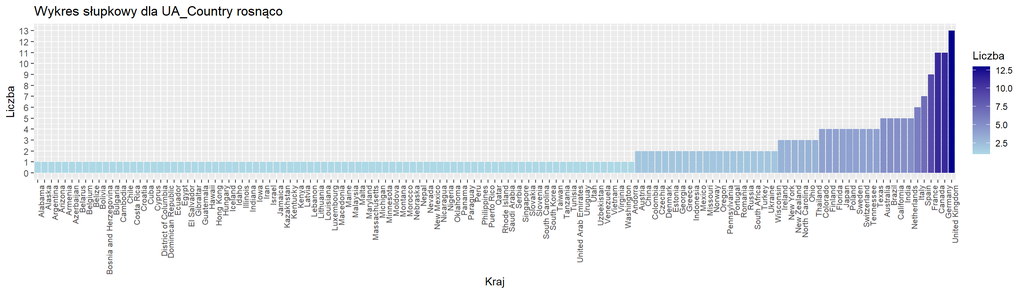

kolo

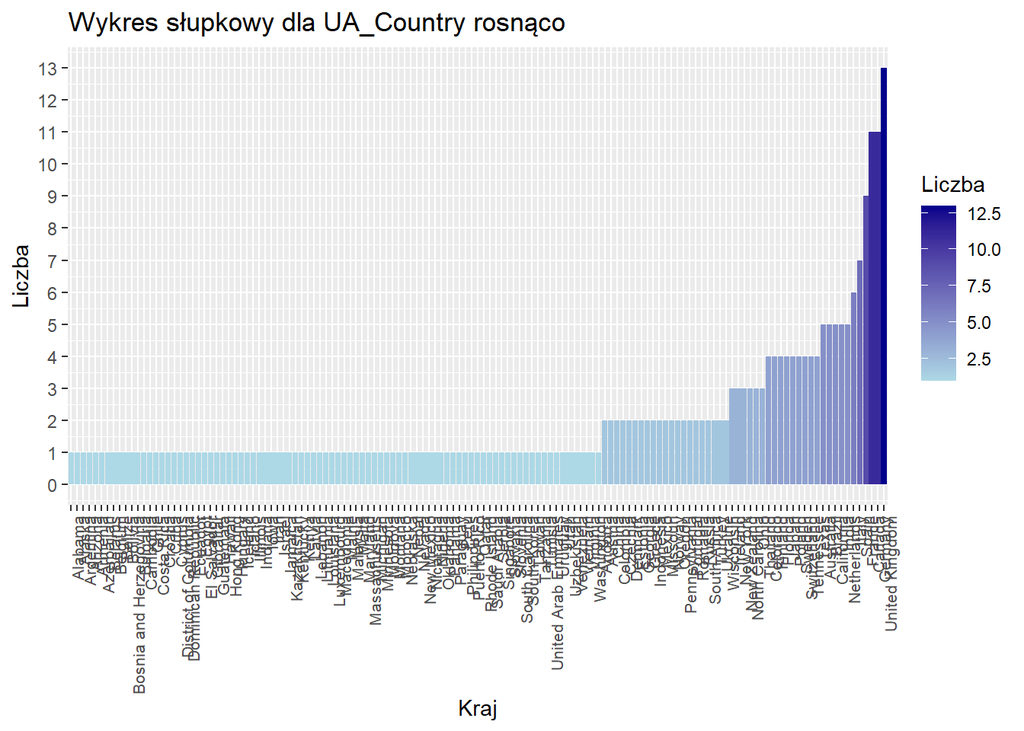

kolo

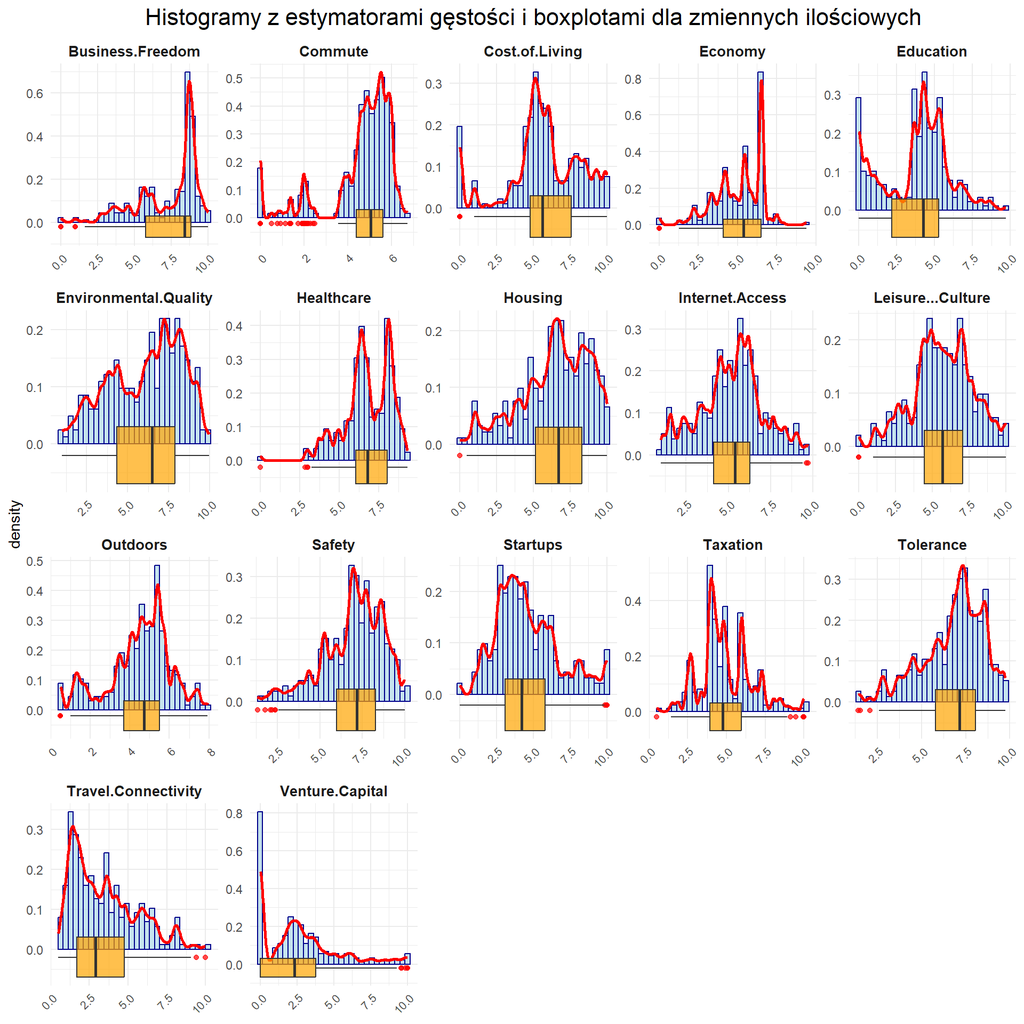

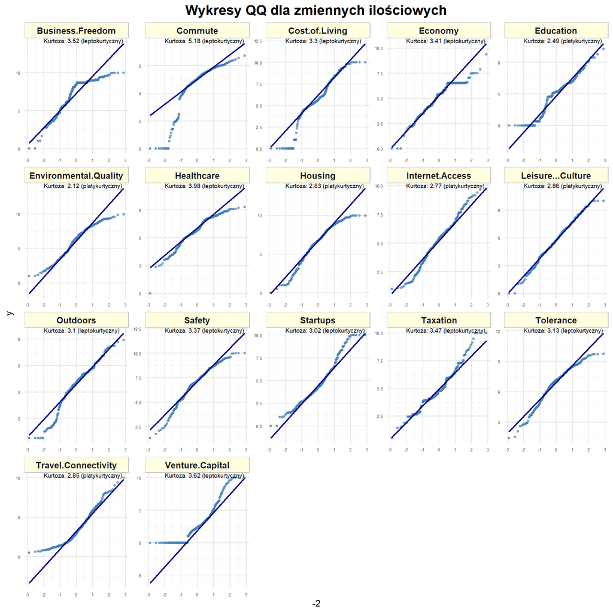

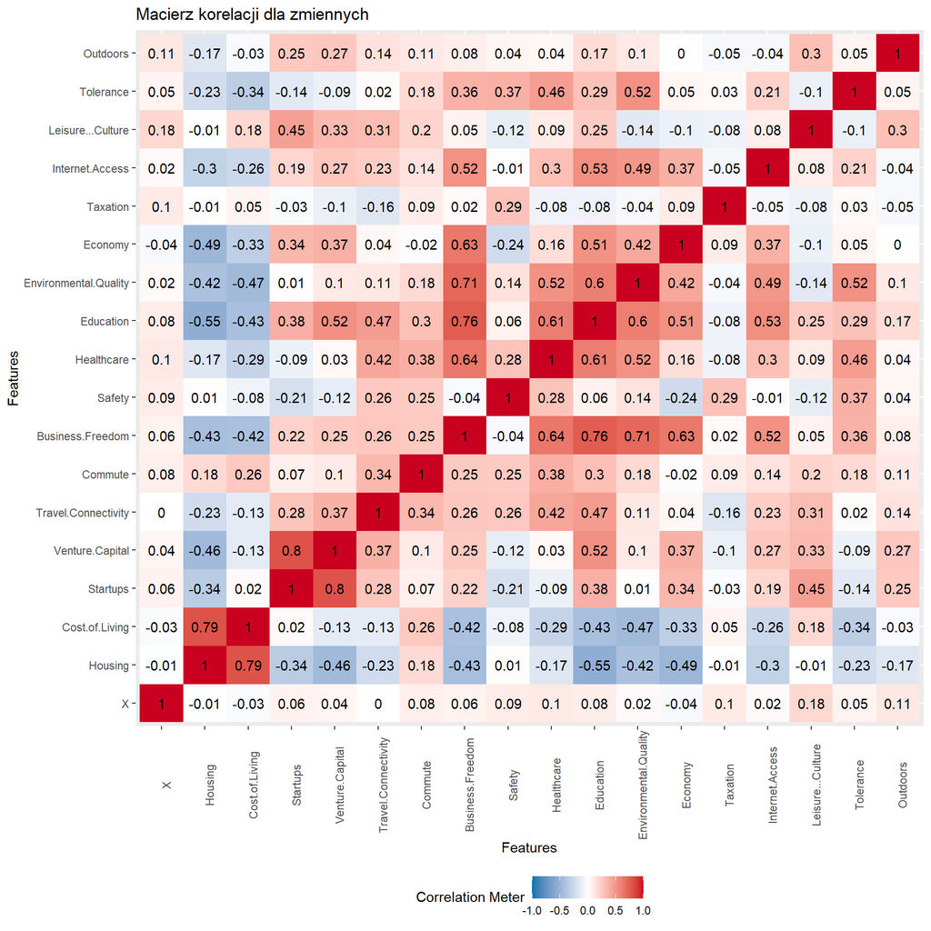

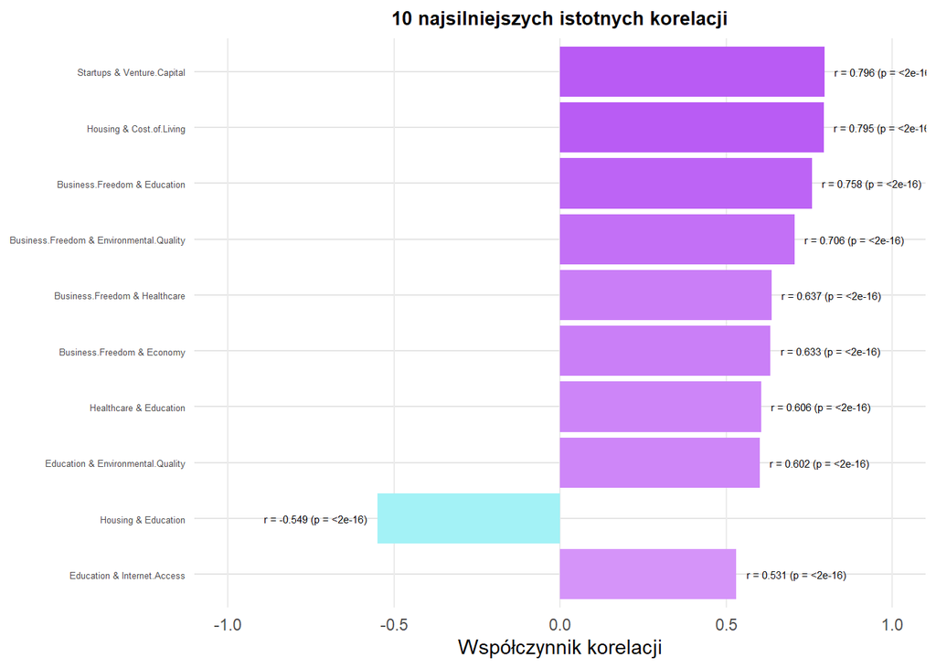

| X | UA_Name | UA_Country | UA_Continent | Housing | Cost.of.Living |
| --- | --- | --- | --- | --- | --- |
| 0 | Aarhus | Denmark | Europe | 6.132 | 4.015 |
| 1 | Adelaide | Australia | Oceania | 6.310 | 4.692 |
| 2 | Albuquerque | New Mexico | North America | 7.262 | 6.059 |
| 3 | Almaty | Kazakhstan | Asia | 9.282 | 9.333 |
| 4 | Amsterdam | Netherlands | Europe | 3.053 | 3.824 |
| 5 | Anchorage | Alaska | North America | 5.434 | 3.141 |

| X | Startups | Venture.Capital | Travel.Connectivity | Commute | Business.Freedom |
| --- | --- | --- | --- | --- | --- |
| 0 | 2.827 | 2.512 | 3.536 | 6.312 | 9.940 |
| 1 | 3.136 | 2.640 | 1.777 | 5.336 | 9.400 |
| 2 | 3.772 | 1.493 | 1.456 | 5.056 | 8.671 |
| 3 | 2.458 | 0.000 | 4.592 | 5.871 | 5.568 |
| 4 | 7.972 | 6.107 | 8.325 | 6.118 | 8.837 |
| 5 | 2.795 | 0.000 | 1.738 | 4.715 | 8.671 |

| X | Safety | Healthcare | Education | Environmental.Quality | Economy |
| --- | --- | --- | --- | --- | --- |
| 0 | 9.617 | 8.704 | 5.367 | 7.633 | 4.887 |
| 1 | 7.926 | 7.937 | 5.142 | 8.331 | 6.070 |
| 2 | 1.343 | 6.430 | 4.152 | 7.319 | 6.514 |
| 3 | 7.309 | 4.546 | 2.283 | 3.857 | 5.269 |
| 4 | 8.504 | 7.907 | 6.180 | 7.597 | 5.053 |
| 5 | 3.470 | 6.060 | 3.624 | 9.272 | 6.514 |

| X | Taxation | Internet.Access | Leisure…Culture | Tolerance | Outdoors |
| --- | --- | --- | --- | --- | --- |
| 0 | 5.068 | 8.373 | 3.187 | 9.739 | 4.130 |
| 1 | 4.588 | 4.341 | 4.328 | 7.822 | 5.531 |
| 2 | 4.346 | 5.396 | 4.890 | 7.028 | 3.515 |
| 3 | 8.522 | 2.886 | 2.937 | 6.540 | 5.500 |
| 4 | 4.955 | 4.523 | 8.874 | 8.368 | 5.307 |
| 5 | 4.772 | 4.964 | 3.266 | 7.093 | 5.358 |

|  | Wariancja |
| --- | --- |
| Housing | 5.265 |
| Cost.of.Living | 5.988 |
| Startups | 4.635 |
| Venture.Capital | 6.520 |
| Travel.Connectivity | 4.375 |
| Commute | 2.320 |
| Business.Freedom | 4.450 |
| Safety | 3.051 |
| Healthcare | 2.196 |
| Education | 4.897 |
| Environmental.Quality | 4.840 |
| Economy | 2.302 |
| Taxation | 2.855 |
| Internet.Access | 3.505 |
| Leisure…Culture | 4.027 |
| Tolerance | 2.974 |
| Outdoors | 2.534 |

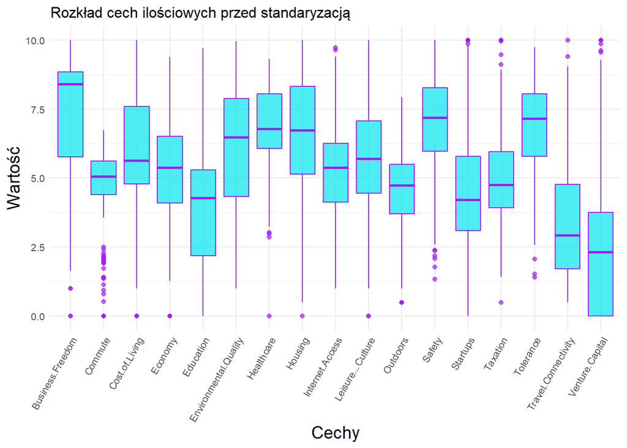

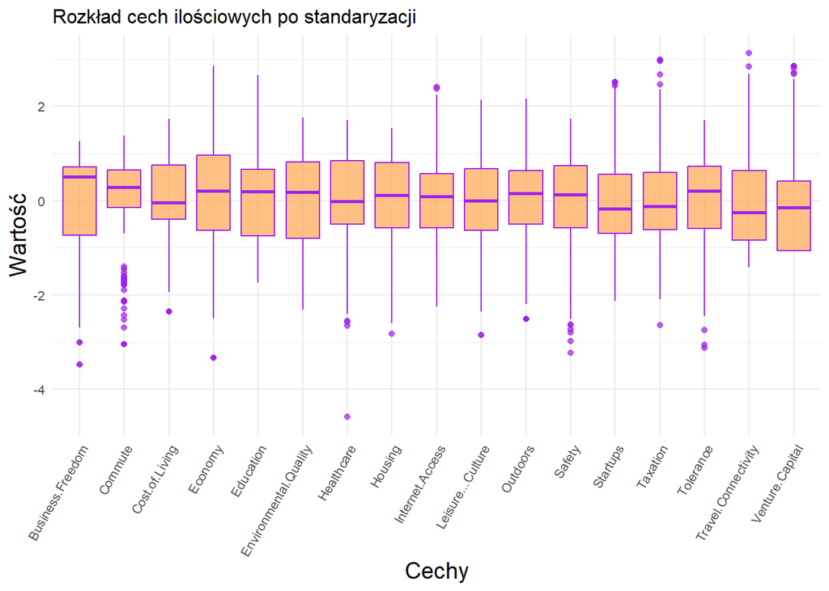

## b) Wyznaczenie składowych głównych

Podsumowanie analizy PCA

| Składowa | Odchylenie_standardowe | Procent_wariancji | Kumulatywna_wariancja |
| --- | --- | --- | --- |
| PC1 | 2.251 | 29.80 | 29.80 |
| PC2 | 1.606 | 15.16 | 44.96 |
| PC3 | 1.443 | 12.25 | 57.21 |
| PC4 | 1.140 | 7.65 | 64.86 |
| PC5 | 1.095 | 7.05 | 71.90 |
| PC6 | 0.980 | 5.65 | 77.55 |
| PC7 | 0.831 | 4.06 | 81.62 |
| PC8 | 0.815 | 3.90 | 85.52 |
| PC9 | 0.764 | 3.43 | 88.95 |
| PC10 | 0.651 | 2.50 | 91.45 |
| PC11 | 0.569 | 1.90 | 93.35 |
| PC12 | 0.539 | 1.71 | 95.06 |
| PC13 | 0.524 | 1.62 | 96.68 |
| PC14 | 0.434 | 1.11 | 97.79 |
| PC15 | 0.393 | 0.91 | 98.69 |
| PC16 | 0.352 | 0.73 | 99.42 |
| PC17 | 0.313 | 0.58 | 100.00 |

## c) Zmienność odpowiadająca poszczególnym składowym

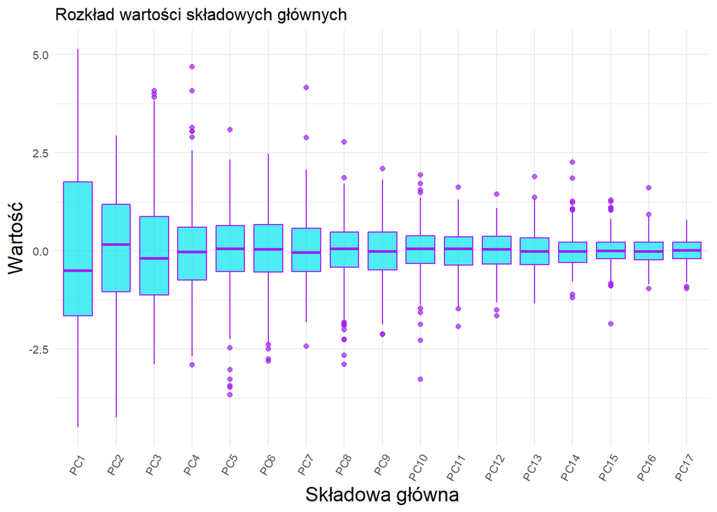

Wektory ładunków dla PC1, PC2 i PC3

|  | PC1 | PC2 | PC3 |
| --- | --- | --- | --- |
| Housing | 0.3078251 | 0.0533534 | -0.3135465 |
| Cost.of.Living | 0.2596091 | -0.1757815 | -0.3305352 |
| Startups | -0.1802385 | -0.4834415 | 0.0061000 |
| Venture.Capital | -0.2365974 | -0.4274509 | 0.0148768 |
| Travel.Connectivity | -0.2094543 | -0.1353067 | -0.3397760 |
| Commute | -0.1142045 | 0.0259310 | -0.5057359 |
| Business.Freedom | -0.3772809 | 0.0982196 | 0.0241046 |
| Safety | -0.0389355 | 0.2871039 | -0.3330100 |
| Healthcare | -0.2803590 | 0.2419482 | -0.2810248 |
| Education | -0.4025620 | -0.0490795 | -0.0738645 |
| Environmental.Quality | -0.3262220 | 0.2525355 | 0.0535717 |
| Economy | -0.2731752 | -0.0740033 | 0.3086705 |
| Taxation | 0.0262992 | 0.1074151 | -0.0201849 |
| Internet.Access | -0.2761922 | 0.0227056 | 0.0284416 |
| Leisure…Culture | -0.0744466 | -0.3647324 | -0.3050545 |
| Tolerance | -0.1897496 | 0.3550911 | -0.1027251 |
| Outdoors | -0.0915866 | -0.1933825 | -0.1485868 |

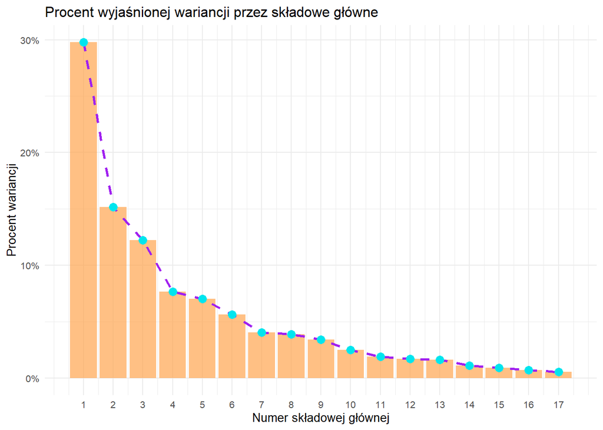

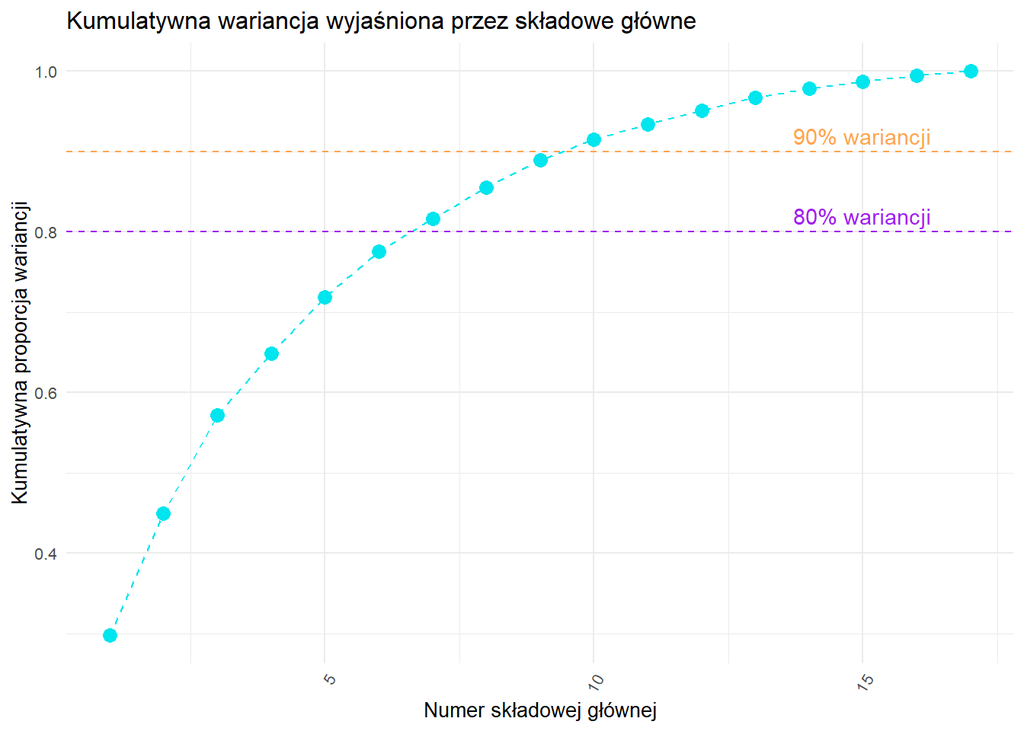

Liczba składowych głównych wyjaśniających **80%** wariancji: **7**  
Liczba składowych głównych wyjaśniających **90%** wariancji: **10**

## d) Wizualizacja danych wielowymiarowych

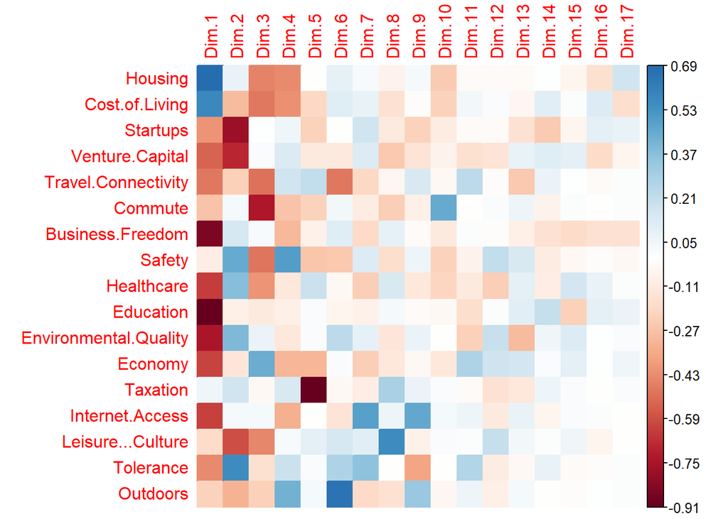

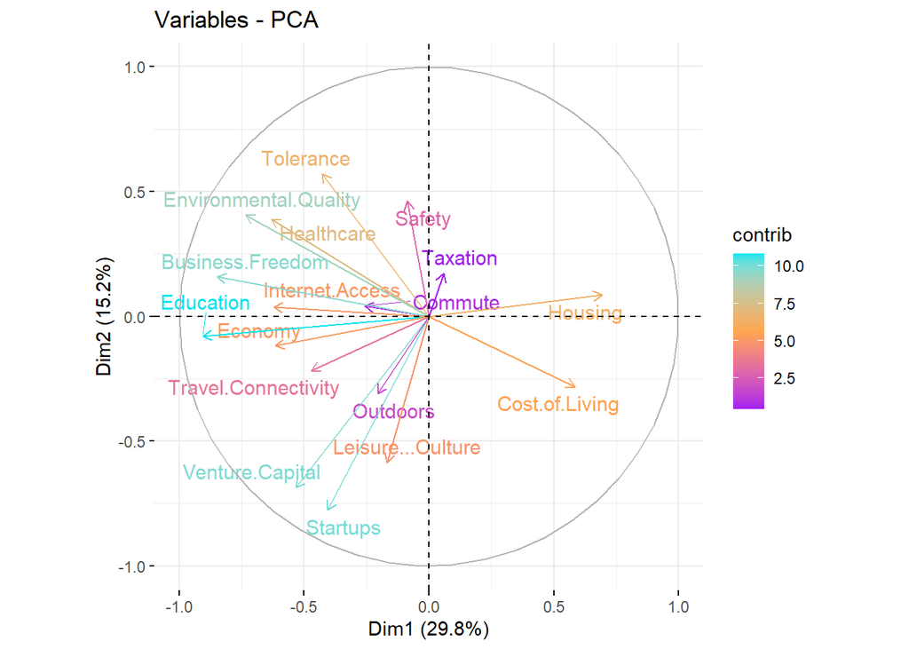

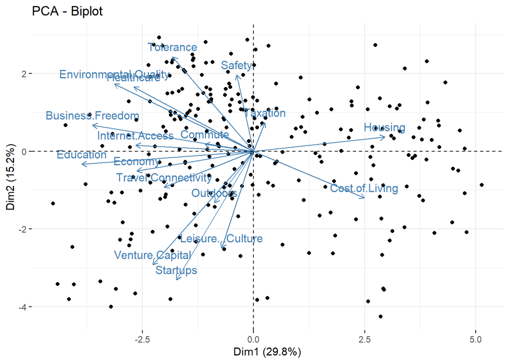

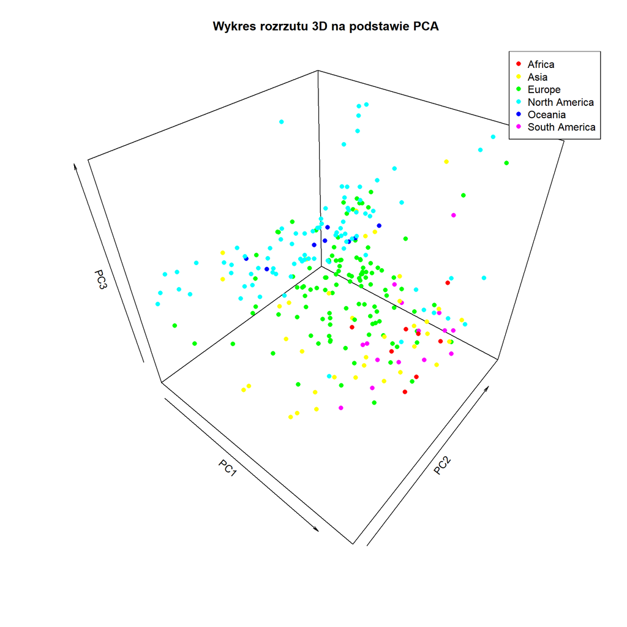